# HMM在股票市场中的应用

我们假设隐藏状态数量是6，即假设股市的状态有6种，虽然我们并不知道每种状态到底是什么，但是通过后面的图我们可以看出那种状态下市场是上涨的，哪种是震荡的，哪种是下跌的。可观测的特征状态我们选择了3个指标进行标示，进行预测的时候假设假设所有的特征向量的状态服从高斯分布，这样就可以使用 hmmlearn 这个包中的 GaussianHMM 进行预测了。下面我会逐步解释。

首先导入必要的包：

```python
from hmmlearn.hmm import GaussianHMM
import numpy as np
from matplotlib import cm, pyplot as plt
import matplotlib.dates as dates
import pandas as pd
import datetime
```

测试时间从2005年1月1日到2015年12月31日，拿到每日沪深300的各种交易数据。

```python
beginDate = '2005-01-01'
endDate = '2015-12-31'
n = 6 #6个隐藏状态
data = get_price('CSI300.INDX',start_date=beginDate, end_date=endDate,frequency='1d')
data.to_csv("sorted_1000.csv", sep=' ')
data[0:9]
```

| MDEntryDate | ClosingPx | HighPx | LowPx | NextTradingDate | OpeningPx | TotalTurnover | TotalVolumeTraded |
| --- | --- | --- | --- | --- | --- | --- | --- |
| 2005-01-04 | 982.79 | 994.77 | 980.66 | 20050105 | 994.77 | 4431976960 | 7412869 |
| 2005-01-05 | 992.56 | 997.32 | 979.88 | 20050106 | 981.58 | 4529207808 | 7119109 |
| 2005-01-06 | 983.17 | 993.79 | 980.33 | 20050107 | 993.33 | 3921015040 | 6288028 |
| 2005-01-07 | 983.96 | 995.71 | 979.81 | 20050110 | 983.05 | 4737468928 | 7298694 |
| 2005-01-10 | 993.88 | 993.96 | 979.79 | 20050111 | 983.76 | 3762931968 | 5791697 |
| 2005-01-11 | 997.14 | 999.55 | 991.09 | 20050112 | 994.19 | 3704076032 | 5849079 |
| 2005-01-12 | 996.75 | 996.98 | 989.26 | 20050113 | 996.65 | 3093298944 | 5014525 |
| 2005-01-13 | 996.88 | 999.47 | 992.70 | 20050114 | 996.08 | 3842172928 | 6044065 |
| 2005-01-14 | 988.31 | 1006.46 | 987.23 | 20050117 | 996.62 | 4162920960 | 7297842 |

拿到每日成交量和收盘价的数据。

```python
volume = data['TotalVolumeTraded']
close = data['ClosingPx']
```

计算每日最高最低价格的对数差值，作为特征状态的一个指标。

```python
logDel = np.log(np.array(data['HighPx'])) - np.log(np.array(data['LowPx']))
logDel
```

```
array([ 0.01428574,  0.01764157,  0.01363667, ...,  0.01380317,
        0.01051247,  0.01207808])
```

计算每5日的指数对数收益差，作为特征状态的一个指标。

```python
logRet_1 = np.array(np.diff(np.log(close)))#这个作为后面计算收益使用
logRet_5 = np.log(np.array(close[5:])) - np.log(np.array(close[:-5]))
logRet_5
```

```
array([ 0.01449572,  0.00421252,  0.01384836, ..., -0.03007529,
       -0.02652464, -0.02603115])
```

计算每5日的指数成交量的对数差，作为特征状态的一个指标。

```python
logVol_5 = np.log(np.array(volume[5:])) - np.log(np.array(volume[:-5]))
logVol_5
```

```
array([-0.23693333, -0.35044388, -0.03957071, ..., -0.57079226,
       -0.67285963, -0.36793342])
```

由于计算中出现了以5天为单位的计算，所以要调整特征指标的长度。

```python
logDel = logDel[5:]
logRet_1 = logRet_1[4:]
close = close[5:]
Date = pd.to_datetime(data.index[5:])
```

把我们的特征状态合并在一起。

```python
A = np.column_stack([logDel,logRet_5,logVol_5])
A
```

```
array([[ 0.00849983,  0.01449572, -0.23693333],
       [ 0.00777352,  0.00421252, -0.35044388],
       [ 0.00679663,  0.01384836, -0.03957071],
       ...,
       [ 0.01380317, -0.03007529, -0.57079226],
       [ 0.01051247, -0.02652464, -0.67285963],
       [ 0.01207808, -0.02603115, -0.36793342]])
```

下面运用 hmmlearn 这个包中的 GaussianHMM 进行预测。

```python
model = GaussianHMM(n_components= n, covariance_type="full", n_iter=2000).fit([A])
hidden_states = model.predict(A)
hidden_states
```

```
array([0, 0, 0, ..., 3, 3, 3])
```

关于 covariance_type 的参数有下面四种：

spherical：是指在每个马尔可夫隐含状态下，可观察态向量的所有特性分量使用相同的方差值。对应协方差矩阵的非对角为0，对角值相等，即球面特性。这是最简单的高斯分布PDF。

[figure not shown]

diag：是指在每个马尔可夫隐含状态下，可观察态向量使用对角协方差矩阵。对应协方差矩阵非对角为0，对角值不相等。diag是hmmlearn里面的默认类型。

[figure not shown]

full：是指在每个马尔可夫隐含状态下，可观察态向量使用完全协方差矩阵。对应的协方差矩阵里面的元素都是不为零。

[figure not shown]

tied：是指所有的马尔可夫隐含状态使用相同的完全协方差矩阵。

这四种PDF类型里面，spherical, diag和full代表三种不同的高斯分布概率密度函数，而tied则可以看作是GaussianHMM和GMMHMM的特有实现。其中，full是最强大的，但是需要足够多的数据来做合理的参数估计；spherical是最简单的，通常用在数据不足或者硬件平台性能有限的情况之下；而diag则是这两者一个折中。在使用的时候，需要根据可观察态向量不同特性的相关性来选择合适的类型。

转自知乎用户Aubrey Li

我们把每个预测的状态用不同颜色标注在指数曲线上看一下结果。

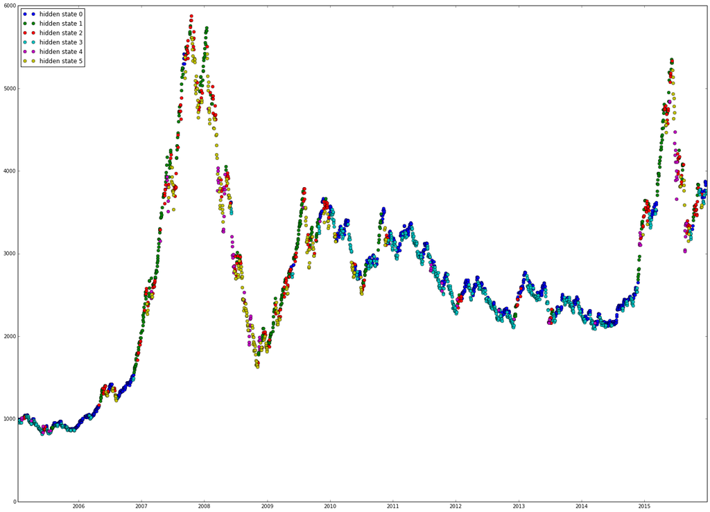

```python
plt.figure(figsize=(25, 18))
for i in range(model.n_components):
    pos = (hidden_states==i)
    plt.plot_date(Date[pos],close[pos],'o',label='hidden state %d'%i,lw=2)
    plt.legend(loc="left")
```

从图中可以比较明显的看出绿色的隐藏状态代表指数大幅上涨，浅蓝色和黄色的隐藏状态代表指数下跌。

为了更直观的表现不同的隐藏状态分别对应了什么，我们采取获得隐藏状态结果后第二天进行买入的操作，这样可以看出每种隐藏状态代表了什么。

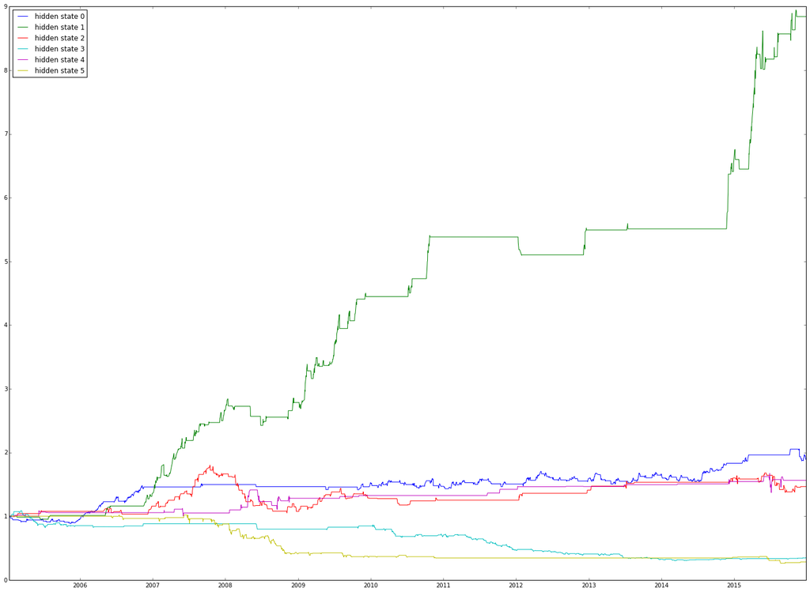

```python
res = pd.DataFrame({'Date':Date,'logRet_1':logRet_1,'state':hidden_states}).set_index('Date')
plt.figure(figsize=(25, 18))
for i in range(model.n_components):
    pos = (hidden_states==i)
    pos = np.append(0,pos[:-1])#第二天进行买入操作
    df = res.logRet_1
    res['state_ret%s'%i] = df.multiply(pos)
    plt.plot_date(Date,np.exp(res['state_ret%s'%i].cumsum()),'-',label='hidden state %d'%i)
    plt.legend(loc="left")
```

可以看到，隐藏状态1是一个明显的大牛市阶段，隐藏状态0是一个缓慢上涨的阶段(可能对应反弹)，隐藏状态3和5可以分别对应震荡下跌的大幅下跌。其他的两个隐藏状态并不是很明确。由于股指期货可以做空，我们可以进行如下操作：当处于状态0和1时第二天做多，当处于状态3和5第二天做空，其余状态则不持有。

```python
long = (hidden_states==0) + (hidden_states == 1) #做多
short = (hidden_states==3) + (hidden_states == 5)  #做空
long = np.append(0,long[:-1]) #第二天才能操作
short = np.append(0,short[:-1]) #第二天才能操作
```

收益曲线图如下：

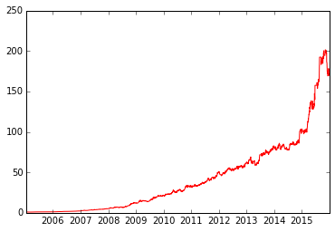

```python
res['ret'] =  df.multiply(long) - df.multiply(short)
plt.plot_date(Date,np.exp(res['ret'].cumsum()),'r-')
```

可以看到效果还是很不错的。但事实上该结果是有些问题的。真实操作时，我们并没有未来的信息来训练模型。不过可以考虑用历史数据进行训练，再对之后的数据进行预测。